# R nad SQL DB - ukol nakaza - s.106

# DB conection

```r
library(DBI)
library(odbc)
con <- dbConnect(odbc(),
                 Driver = "ODBC Driver 17 for SQL Server",
                 Server = "REX\\SQLEXPRESS",
                 Database = "VYUKA_DATABAZE",
                 Trusted_Connection="yes",
                 encoding = "CP1250")
```

# Zadanie:

- Využite skôr vytvorenú SQL funkciu nakaza_po_dnech(datum-od, datum-do), ktorá umožňuje zobrazovať počet nakazených, vyliečených a zomrelých na COVID-19 za sledované obdobie po dňoch. Dáta sledujte od 08/220 po 03/2021. Dáta vhodne časovo zoraďte.
- Data načítajte ako dátovú tabuľku do R.
- Tabuľku doplňte o počet aktívnych prípadov v jednotlivých dňoch - skriptom v R. Vykreslite graf počtu aktívnych prípadov v závislosti na čase.
- Uvažujte len dáta od 1.8. do 1.11. 2020. Dá sa povedať, že počet aktívnych prípadov expoennciálne rastie? Overte prostredníctvom lineárnej regresie.

# Riešenie:

## Načítanie dát využitím SQL funkcie

- Využite skôr vytvorenú SQL funkciu nakaza_po_dnech(datum-od, datum-do), ktorá umožňuje zobrazovať počet nakazených, vyliečených a zomrelých na COVID-19 za sledované obdobie po dňoch. Dáta sledujte od 08/220 po 03/2021. Dáta vhodne časovo zoraďte.

### SQL funkcia:

```sql
ALTER FUNCTION [dbo].[nakaza_po_dnech]
(
  @datum_od AS date,
  @datum_do AS date
)
RETURNS TABLE AS
RETURN
(
  SELECT 0 AS my_order,
        NULL AS datum,
        SUM(CASE n.typ_hlaseni WHEN 'N' THEN 1 else 0 end) AS nakaza,
        SUM(CASE n.typ_hlaseni WHEN 'U' THEN 1 else 0 end) AS umrti,
        SUM(CASE n.typ_hlaseni WHEN 'V' THEN 1 else 0 end) AS vyleceni
  FROM [dbo].[nakaza] n
  WHERE n.nak_datum_hlaseni<@datum_od
  UNION
  SELECT 1 AS my_order,
         n.nak_datum_hlaseni AS datum,
         SUM(CASE n.typ_hlaseni WHEN 'N' THEN 1 else 0 end) AS nakaza,
         SUM(CASE n.typ_hlaseni WHEN 'U' THEN 1 else 0 end) AS umrti,
         SUM(CASE n.typ_hlaseni WHEN 'V' THEN 1 else 0 end) AS vyleceni
  FROM [dbo].[nakaza] n
  WHERE n.nak_datum_hlaseni>=@datum_od and n.nak_datum_hlaseni<=@datum_do
  GROUP BY n.nak_datum_hlaseni
  UNION
  SELECT 2 AS my_order,
          NULL AS datum,
          SUM(CASE n.typ_hlaseni WHEN 'N' THEN 1 else 0 end) AS nakaza,
          SUM(CASE n.typ_hlaseni WHEN 'U' THEN 1 else 0 end) AS umrti,
          SUM(CASE n.typ_hlaseni WHEN 'V' THEN 1 else 0 end) AS vyleceni
  FROM [dbo].[nakaza] n WHERE n.nak_datum_hlaseni>@datum_do )
```

Celkovo táto funkcia vracia tabuľku s tromi časťami:

Stĺpec `my_order` slúži na zoradenie výsledkov: najskôr kumulatívne dáta pred zadaným obdobím, potom denné dáta v zadanom období a nakoniec kumulatívne dáta po zadanom období.

- Dáta načítajte ako tabuľku do R:

```r
data<-dbGetQuery(con,
  "SELECT *
  FROM [dbo].[nakaza_po_dnech] ('2020-08-01','2021-03-31')
  ORDER BY my_order,datum")
```

Ukážka dát:

```r
data |> head()
```

```
##   my_order      datum nakaza umrti vyleceni
## 1        0       <NA>  16608   382    13244
## 2        1 2020-08-01    124     2       75
## 3        1 2020-08-02    101     2       93
## 4        1 2020-08-03    208     2      225
## 5        1 2020-08-04    287     2      233
## 6        1 2020-08-05    241     1      196
```

```r
data |> tail()
```

```
##     my_order      datum nakaza umrti vyleceni
## 240        1 2021-03-27   3982   181     4242
## 241        1 2021-03-28   1747   117     3342
## 242        1 2021-03-29   6954   181    14525
## 243        1 2021-03-30   8653   171    12675
## 244        1 2021-03-31   7279   153    11014
## 245        2       <NA>  99914  2725   165401
```

## Počet aktívnych prípadov

- Tabuľku doplňte o počet aktívnych prípadov v jednotlivých dňoch - skriptom v R. Vykreslite graf počtu aktívnych prípadov v závislosti na čase.

```r
data$active_cases<-cumsum(data$nakaza-data$umrti-data$vyleceni)
data |> head()
```

```
##   my_order      datum nakaza umrti vyleceni active_cases
## 1        0       <NA>  16608   382    13244         2982
## 2        1 2020-08-01    124     2       75         3029
## 3        1 2020-08-02    101     2       93         3035
## 4        1 2020-08-03    208     2      225         3016
## 5        1 2020-08-04    287     2      233         3068
## 6        1 2020-08-05    241     1      196         3112
```

```r
data |> tail()
```

```
##     my_order      datum nakaza umrti vyleceni active_cases
## 240        1 2021-03-27   3982   181     4242       116980
## 241        1 2021-03-28   1747   117     3342       115268
## 242        1 2021-03-29   6954   181    14525       107516
## 243        1 2021-03-30   8653   171    12675       103323
## 244        1 2021-03-31   7279   153    11014        99435
## 245        2       <NA>  99914  2725   165401        31223
```

## Vykresliť graf

Prvy riadok má v stlpci `my_order` hodnotu 0, posledný hodnotu 2. Sú to dáta pre obdobie mimo intervalu

```r
data$active_cases[data$my_order!=1]<-NA
data |> head(2)
```

```
##   my_order      datum nakaza umrti vyleceni active_cases
## 1        0       <NA>  16608   382    13244           NA
## 2        1 2020-08-01    124     2       75         3029
```

```r
data |> tail(2)
```

```
##     my_order      datum nakaza umrti vyleceni active_cases
## 244        1 2021-03-31   7279   153    11014        99435
## 245        2       <NA>  99914  2725   165401           NA
```

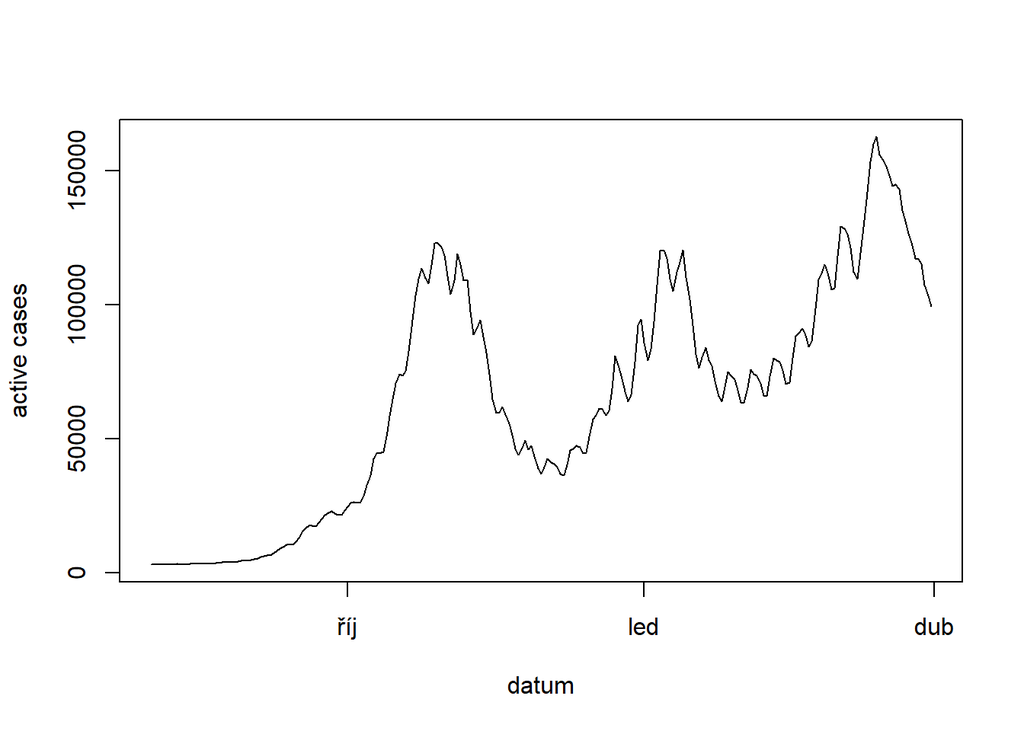

```r
plot(data$datum,
     data$active_cases, type = 'l', xlab="datum", ylab="active cases")
```

## Exponenciálna regresia

```r
data.1<-data[data$datum<=as.Date('2020-10-31') & !is.na(data$datum),]
# datum nie je NA a je to skor ako 1.11.2020

data |> dim() # povodne rozmery dat
```

```
## [1] 245   6
```

```r
data.1 |> dim() # rozmery dat pri skratení dátumu do 30.10.2020
```

```
## [1] 92  6
```

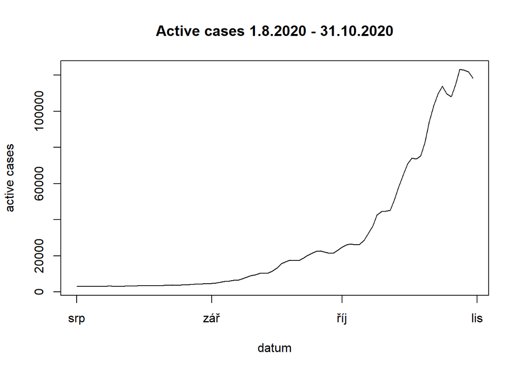

```r
plot(data.1$datum,
     data.1$active_cases, type = 'l',
     xlab="datum",ylab="active cases",
     main = "Active cases 1.8.2020 - 31.10.2020")
```

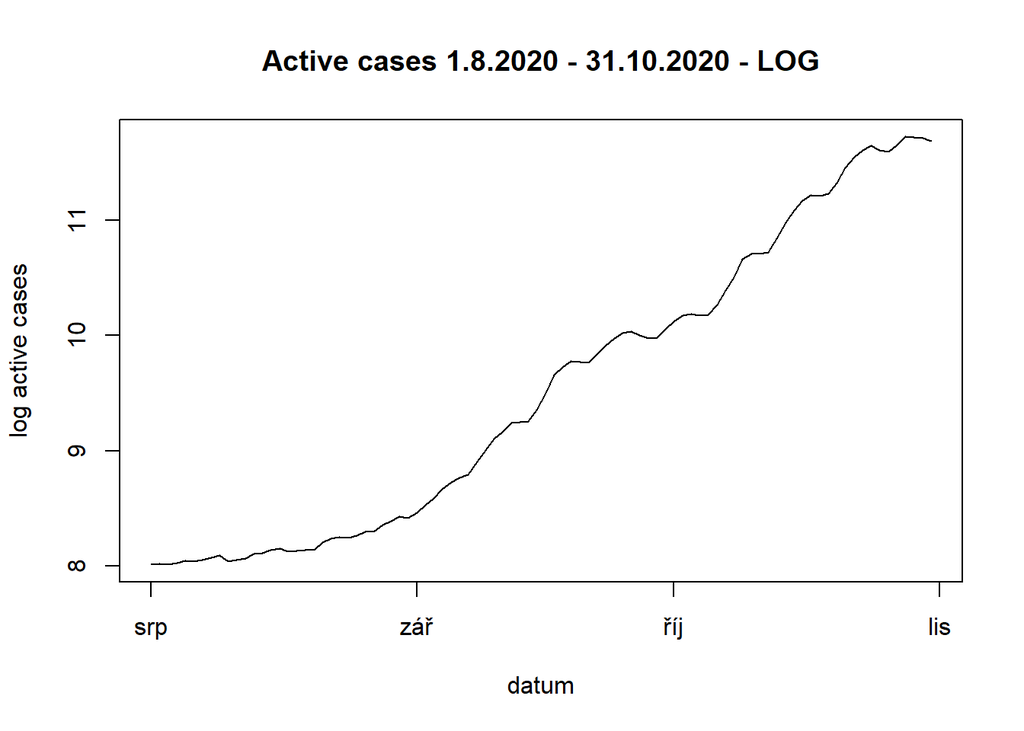

```r
plot(data.1$datum,
     log(data.1$active_cases), type = 'l',
     xlab="datum",
     ylab="log active cases",
     main = "Active cases 1.8.2020 - 31.10.2020 - LOG")
```

## Linearna regresia pre pocet pripadov

```r
x<-1:nrow(data.1) # Vektor prirodzenych cisel od 1 po pocet riadkov matice data.1
y<-log(data.1$active_cases) # logaritmus poctu pripadov

reg<-lm(y~x)
  # x = očíslované dni
  # y = log(pocet pripadov)

reg$coefficients # koeficienty regresnej rovnice
```

```
## (Intercept)           x
##  7.35740062  0.04665952
```

### Graf s trendovou rovnicou

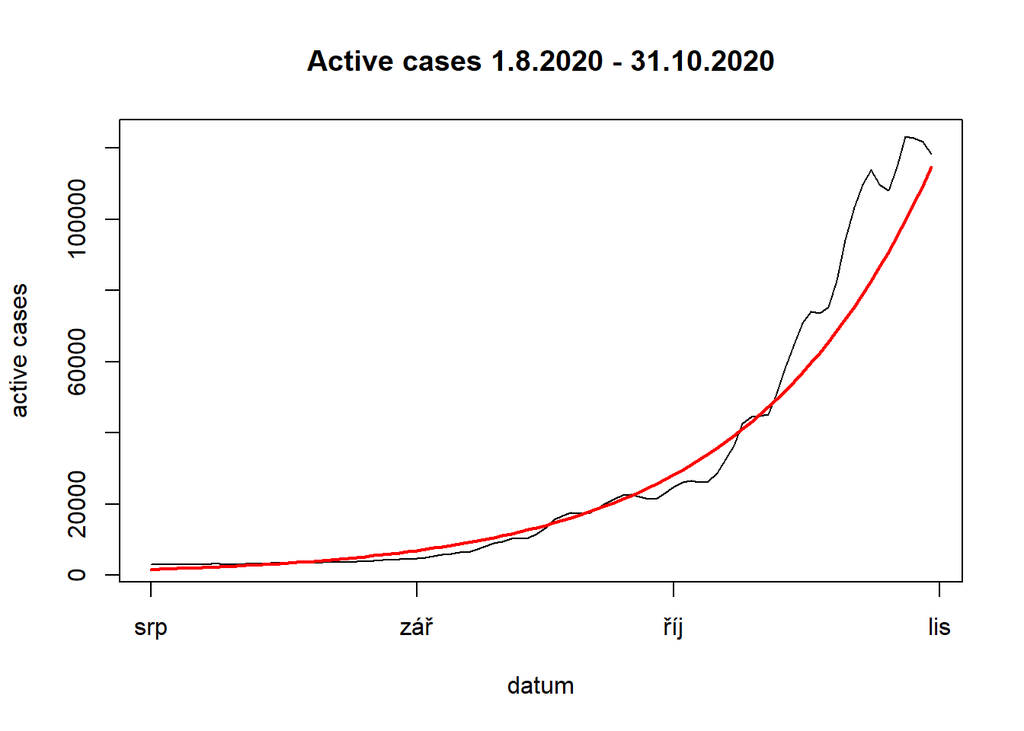

```r
# rovnaký graf ako vyššie
plot(data.1$datum,
     data.1$active_cases,
     type = 'l',
     xlab="datum",ylab="active cases",
     main = "Active cases 1.8.2020 - 31.10.2020")

# pridanie trendovej čiary
lines(data.1$datum, # x - poradové číslo dňa
      exp(reg$coefficients[1] + reg$coefficients[2]*x), # y -> z regresnej rovnice
      col='red',lwd=2)
```

### Diagnostické grafy pre regresiu

- Residuá vs. Predikované hodnoty
- Normálny kvantil-kvantilový graf
- Spread-level graf
- Reziduály vs. páka

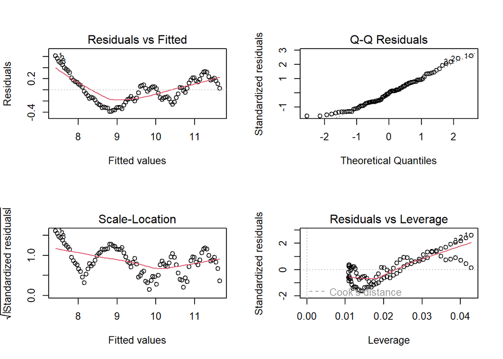

```r
par(mfrow=c(2,2))
plot(reg)
```

```r
par(mfrow=c(1,1))
```